# Sobol ODE Assignment

2024 May 7th

Task # 1. Implement model in R

Create the model as a function:

```r
# version 1
dforestgrowth = function(Time, C, parms) {

  if(C < 50) { # the canopy threshold

    dG = parms$r * C
  } else {

    dG = parms$r * (1- C/parms$K)
  }

  return(list(dG))
}

# adjusted
dforestgrowth = function(Time, C, parms, thresh) { # added thresh

  if(C < thresh) {

    dG = parms$r * C
  } else {

    dG = parms$g * (1- C/parms$K) # updated the g parameter
  }

  return(list(dG))
}
```

```r
# read in the function
source("../../R/dforestgrowth.R")
```

# 2. Run model for 300 years (using ODE solver)

Initial conditions - initial forest size of 10 kg/C - canopy closure threshold of 50 kgC - K = 250 kg C (carrying capacity) - r= 0.01 (exponential growth rate before before canopy closure) - g = 2 kg/year (linear growth rate after canopy closure)

Run for 300 years

```r
# initial forest size
time = seq(1, 300)
Cinitial = 10
thresh = 50
K = 250
r = 0.01
g = 2

parms = list(K = 250, r = 0.01, g = 2, thresh = 50)
result = ode(y=Cinitial,
             times=time,
             func=dforestgrowth, # growth function
             parms =parms,
             thresh = thresh)

result <- as.data.frame(result)
```

# 3. Graph Results

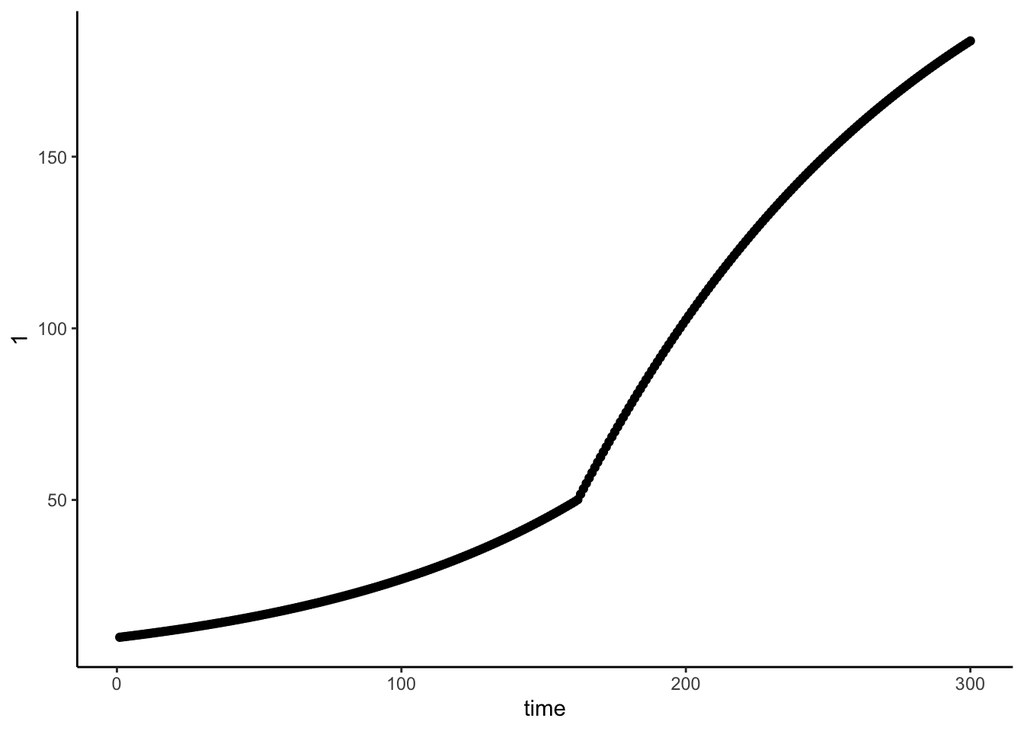

```r
ggplot(result, aes(time, `1`)) +
  geom_point() +
  theme_classic()
```

# 4. Run sobol global

Sensitivity analysis that explores how the estimated maximum forest size (e.g maximum of C 300 years), varies with these parameters

- pre canopy closure growth rate (r)
- post-canopy closure growth rate (g)
- canopy closure threshold and carrying capacity(K)

Set up the normal distributions for parameters:

```r
# generate the sobel parameters
np=2000
K = rnorm(mean=250, sd=250*0.01, n=np)
r = rnorm(mean=0.01, sd=0.01*0.01, n=np)
g = rnorm(mean = 2, sd = 2*0.01, n = np)
X1 = cbind.data.frame(r=r, K=K, g = g)

# repeat to get our second set of samples
K = rnorm(mean=250, sd=250*0.01, n=np)
r = rnorm(mean=0.01, sd=0.01*0.01, n=np)
g = rnorm(mean = 2, sd = 2*0.01, n = np)
X2 = cbind.data.frame(r=r, K=K, g = g)

# fix any negative values and they are not meaningful
X1 = X1 %>% map_df(pmax, 0.0)
X2 = X2 %>% map_df(pmax, 0.0)

# run sobel model
sens_P = sobolSalt(model = NULL,X1, X2, nboot = 300)

# lets add names
colnames(sens_P$X) = c("r","K", "g")
```

Get results for 300 years

```r
# gets results for 200 years (evaluating every year)
thresh = 50
simtimes = seq(from=1, to=300)
parms = list(r=sens_P$X[1,"r"],
             K=sens_P$X[1,"K"],
             g=sens_P$X[1,"g"])

# run the ODE solver with these conditions
result = ode(y=Cinitial,
             times=simtimes,
             func=dforestgrowth, # growth function
             parms=parms,
             thresh = thresh)

result = as.data.frame(result)

# rename the column names
colnames(result)=c("time","C")
```

Set up the compute metrics and wrapper functions:

```r
# turn computing our metrics into a function

compute_metrics = function(result, thresh) {

  # select the max result
  maxgrowth = max(result$C)

  # set the results that are greater than the threhold
  idx = which(result$C > thresh)[1] # select the first year its above threshold
  idx = ifelse(is.na(idx), # if no results from greater than threshold
               length(result$C), # then set the index to the length of results
               idx) # if not keep it

  # index the time that the growth passed threshold
  threshyear = result$time[idx]

return(list(maxgrowth=maxgrowth, threshyear=threshyear))
}

# try it on our first parameter set, and look at when it gets to 100
# this works!

# compute_metrics(result, 100)
p_wrapper = function(r, K, g, Cinitial, simtimes, odefunc, metricfunc, thresh) {
    parms = list(r=r, K=K, g=g)
    result = ode(y=Cinitial,
                 times=simtimes,
                 func=odefunc,
                 parms=parms,
                 thresh = thresh)
    colnames(result)=c("time","C")
  # get metrics
  metrics=metricfunc(as.data.frame(result), thresh=100)
  return(metrics)
}

# testing
# this works!
# p_wrapper(r=0.01, K=150, g = 2, Cinitial=3, simtimes=seq(from=1,to=10),
#          odefunc=dforestgrowth, metricfunc=compute_metrics)
```

Apply to everything:

```r
# now use pmap as we did before
all = as.data.frame(sens_P$X) %>%
  pmap(p_wrapper,
       thresh=50,
       Cinitial=Cinitial,
       simtimes=simtimes,
       odefunc=dforestgrowth,
       metricfunc=compute_metrics)

# extract out results from pmap into a data frame
allres = all %>%
  map_dfr(`[`,c("maxgrowth","threshyear"))
```

# 5. Graph results of sensitivity analysis as a box plot of maximum forest size and record the two Sobol indices (S and T).

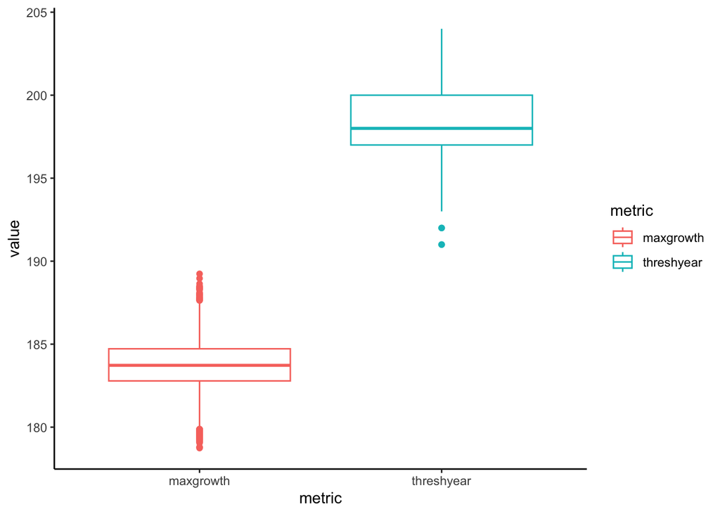

```r
# create boxplots
tmp = allres %>%
  pivot_longer(cols=everything(),
               names_to="metric",
               values_to="value")

ggplot(tmp, aes(metric, value, col=metric)) +
  geom_boxplot() +
  theme_classic()
```

Collect sobol indices

```r
sens_P_maxgrowth = sensitivity::tell(sens_P,
                                  allres$maxgrowth)

# first-order indices (main effect without co-variance)
rownames(sens_P_maxgrowth$S)=c("r","K", "g")
sens_P_maxgrowth$S
```

```
##    original          bias std. error min. c.i. max. c.i.
## r 0.3321122 -0.0008814789 0.01921164 0.2958964 0.3745004
## K 0.4281082 -0.0006024992 0.01873678 0.3883109 0.4672211
## g 0.2531226  0.0013217345 0.02146159 0.2070068 0.2942733
```

```r
# total sensitivity index -note that this partitions the output variance
rownames(sens_P_maxgrowth$T)=c("r","K", "g")
sens_P_maxgrowth$T
```

```
##    original          bias std. error min. c.i. max. c.i.
## r 0.3677481 -0.0008781334 0.01400154 0.3396243 0.3975616
## K 0.4146321  0.0007172455 0.01528847 0.3834366 0.4420764
## g 0.2675347  0.0001251435 0.01023954 0.2459834 0.2868447
```

```r
# create another one for max year
sens_P_threshyear = sensitivity::tell(sens_P,allres$threshyear)
# first-order indices (main effect without co-variance)
rownames(sens_P_threshyear$S)=c("r","K", "g")
sens_P_threshyear$S
```

```
##     original          bias  std. error    min. c.i. max. c.i.
## r 0.91311587 -0.0003305320 0.003501785  0.907195060 0.9197532
## K 0.00858904 -0.0006597248 0.022170492 -0.038805360 0.0500822
## g 0.04053922 -0.0006580561 0.021916342 -0.002501404 0.0876306
```

```r
# total sensitivity index -note that this partitions the output variance - so values sum to 1
rownames(sens_P_threshyear$T)=c("r","K", "g")
sens_P_threshyear$T
```

```
##     original          bias std. error  min. c.i.  max. c.i.
## r 0.96688500  7.502433e-04 0.02321771 0.92578086 1.01494685
## K 0.03142548 -3.554837e-07 0.00166973 0.02795110 0.03462069
## g 0.07715855 -2.385547e-04 0.00304037 0.07116445 0.08258362
```

# 6. Discuss meaning of results of simulation (For example think about how what parameters climate change might influence).

Based on the sensitivity metrics, this means that the max growth is most sensitive to the carrying capacity, but is also very affected by the growth rate, and the threshold year is most sensitive to the growth rate. This is interesting since the growth rate could be affected by warming temperatures, and some forests might experience higher growth rates. This would result in less time to reach carrying capacity / threshold year, which means that there is a potential for changing the long term value of planting that tree. Also, given the rate of deforestation, it would be interesting to examine how the effect of the initial dorest size affects these parameter impacts, and whether there is an impact on what the max growth is.